# S3 Calidad del Sueño

# Introducción

## Tema

Relación entre las horas de sueño de estudiantes universitarios y su desempeño académico en UTEC.

## Relevancia

La relación entre la calidad del sueño y el rendimiento cognitivo en humanos es un tema reciente de investigación. Por un lado, decidimos enfocarnos en estudiantes universitarios porque poseen un horario de sueño muy variado y por ende, una baja calidad de sueño. Esto puede afectar a la memoria (Álvarez Navarrete et al., 2020), aumentar el riesgo de desarrollar demencia o Alzheimer (Lira y Custodio, 2018), y modificar el ritmo circadiano (Saavedra Torres et al., 2013). Por otro lado, nuestra investigación está orientada al desempeño académico debido a que este se ve afectado negativamente por el deterioro de la salud por la falta de sueño. Existen diversos estudios sobre la relación entre las horas del sueño y el rendimiento académico en estudiantes de medicina (Pérez-Olmos, 2006); sin embargo, no encontramos muchos estudios enfocados a estudiantes universitarios en general. En el presente trabajo se emplea una visión más amplia, la cual nos ayuda a identificar mejor las relaciones entre los factores cognitivos afectados, las horas de sueño y el desempeño académico, además de brindarnos facilidad para encontrar los diferentes factores involucrados en la problemática. Por último, la población objeto de estudio está conformada por los estudiantes de la UTEC. Se eligió esta población debido a la conveniencia y accesibilidad para recolectar datos, permitiendo así obtener una muestra representativa de la comunidad estudiantil.

## Objetivo general

- Identificar y describir la relación entre las horas de sueño y el desempeño académico en estudiantes universitarios

## Objetivos específicos

- Evaluar el impacto de las horas de sueño de los estudiantes en su salud.
- Investigar si el número de horas de sueño y su efecto en el desempeño académico varía según la carrera universitaria.
- Determinar si existe una diferencia significativa en el desempeño académico entre los estudiantes universitarios que duermen de 8 horas a más y los que duermen menos de 8 horas.

## Contexto

El presente trabajo utiliza como guía una tesis realizada por Rosales-Mayor (2009) para la generación de preguntas de la encuesta. Esto es porque su trabajo trata sobre adaptar una escala de evaluación de somnolencia para la población peruana.

# Datos

## Proceso de recolección de datos

Para llevar a cabo el proceso de recolección de datos en este estudio sobre las horas de sueño y su relación con el desempeño académico en estudiantes universitarios de UTEC, se utilizó la herramienta Google Forms. A continuación, se presenta una descripción detallada del proceso de recolección de datos:

1. Elección de la herramienta: Se decidió utilizar Google Forms debido a su facilidad de uso, flexibilidad y capacidad para recopilar respuestas de forma organizada y segura.
2. Diseño del cuestionario: Se diseñó un cuestionario que incluía preguntas relevantes para el estudio, como la cantidad promedio de horas de sueño, los hábitos de sueño, el rendimiento académico y otros factores relacionados.
3. Definición de las condiciones: Se establecieron las condiciones necesarias para realizar la recolección de datos. Esto incluye aspectos como la confidencialidad de los datos y verificación de usuario.
4. Estrategias de alcance: Se implementaron estrategias para llegar a la población objetivo, es decir, a los estudiantes de la UTEC. Esto incluye la difusión del cuestionario a través de canales de comunicación internos, como telegram, grupos estudiantiles y redes sociales. Además, se invitó a los estudiantes a responder la encuesta mediante el uso del código QR.
5. Validación y control de calidad: Se realizó un proceso de validación y control de calidad de los datos recolectados para garantizar la consistencia y la integridad de la información obtenida. Esto puede haber involucrado la revisión de respuestas inconsistentes o atípicas, así como la verificación de que no se hayan introducido datos erróneos.

## Cuestionario

[Enlace del cuestionario](https://forms.gle/MToHD7xQz8nwP3Cr9)

## Variables

En el estudio presentamos 24 variables; sin embargo, trabajaremos con 23. Esto es porque la primera es “Marca de Tiempo” la cual es agregada de manera automática por el Google Forms en la base de datos. En el siguiente apartado (Limpieza de base de datos) explicaremos el proceso aplicado para eliminar esta variable de nuestra base de datos. Cargamos los datos:

```r
install.packages("readr",repos='http://cran.us.r-project.org')
install.packages("dplyr", repos='http://cran.us.r-project.org')
library(readr)
library(dplyr)
DP <- read_csv("Encuesta.csv")
```

Observamos que tenemos las siguientes variables:

```r
names(DP)
```

```
##  [1] "Marca temporal" "Edad"           "Ciclo"          "Carrera"
##  [5] "TiempoS"        "CalidadS"       "DificultadD"    "DesempeñoA"
##  [9] "Fatiga"         "Bcafeina"       "Ejercicio"      "NEstres"
## [13] "DispositivoE"   "HEstudio"       "NocheE"         "AbrumadoTA"
## [17] "Siestas"        "AlcoholD"       "OpinionRA"      "Insomnio"
## [21] "CompromisosE"   "EventosA"       "SaludMental"    "Consejo"
```

## Limpieza de base de datos

La encuesta presentaba preguntas de opciones múltiples, esto evita que las observaciones presenten algún dato anormal. Gracias a esto, al revisar los datos, no encontramos respuestas mal escritas, o números fuera de un rango habitual. Por lo tanto, no es necesario realizar una limpieza de datos en este caso. El único problema de esta decisión es que se terminan limitando las respuestas y eliminando la “variedad” de las mismas, ya que hay opciones predeterminadas. Esto se toma como recomendación para futuras investigaciones.

Proceso utilizado para saber si existen datos atípicos u observaciones incompletas:

1. Verificamos si los descriptores tienen lógica:

```r
summary(DP)
```

```
##  Marca temporal          Edad           Ciclo          Carrera
##  Length:138         Min.   :17.00   Min.   : 1.000   Length:138
##  Class :character   1st Qu.:18.00   1st Qu.: 3.000   Class :character
##  Mode  :character   Median :19.00   Median : 4.000   Mode  :character
##                     Mean   :19.33   Mean   : 3.797
##                     3rd Qu.:20.00   3rd Qu.: 4.000
##                     Max.   :25.00   Max.   :10.000
##    TiempoS             CalidadS      DificultadD      DesempeñoA
##  Length:138         Min.   :1.000   Min.   :1.000   Min.   :2.000
##  Class :character   1st Qu.:3.000   1st Qu.:2.000   1st Qu.:3.000
##  Mode  :character   Median :3.000   Median :3.000   Median :3.000
##                     Mean   :3.123   Mean   :2.688   Mean   :3.493
##                     3rd Qu.:4.000   3rd Qu.:3.000   3rd Qu.:4.000
##                     Max.   :5.000   Max.   :5.000   Max.   :5.000
##      Fatiga       Bcafeina          Ejercicio            NEstres
##  Min.   :1.00   Length:138         Length:138         Min.   :1.000
##  1st Qu.:3.00   Class :character   Class :character   1st Qu.:3.000
##  Median :3.00   Mode  :character   Mode  :character   Median :4.000
##  Mean   :3.29                                         Mean   :3.442
##  3rd Qu.:4.00                                         3rd Qu.:4.000
##  Max.   :5.00                                         Max.   :5.000
##   DispositivoE     HEstudio            NocheE            AbrumadoTA
##  Min.   :1.000   Length:138         Length:138         Min.   :1.0
##  1st Qu.:3.250   Class :character   Class :character   1st Qu.:3.0
##  Median :4.000   Mode  :character   Mode  :character   Median :3.5
##  Mean   :4.116                                         Mean   :3.5
##  3rd Qu.:5.000                                         3rd Qu.:4.0
##  Max.   :5.000                                         Max.   :5.0
##     Siestas         AlcoholD      OpinionRA            Insomnio
##  Min.   :1.000   Min.   :1.000   Length:138         Min.   :1.000
##  1st Qu.:1.000   1st Qu.:1.000   Class :character   1st Qu.:1.000
##  Median :2.000   Median :1.000   Mode  :character   Median :2.000
##  Mean   :1.986   Mean   :1.645                      Mean   :2.196
##  3rd Qu.:3.000   3rd Qu.:2.000                      3rd Qu.:3.000
##  Max.   :5.000   Max.   :5.000                      Max.   :5.000
##  CompromisosE          EventosA     SaludMental          Consejo
##  Length:138         Min.   :1.000   Length:138         Length:138
##  Class :character   1st Qu.:2.000   Class :character   Class :character
##  Mode  :character   Median :3.000   Mode  :character   Mode  :character
##                     Mean   :2.659
##                     3rd Qu.:3.750
##                     Max.   :5.000
```

2. Verificamos si hay observaciones incompletas:

```r
table(is.na(DP))
```

```
##
## FALSE
##  3312
```

Por otro lado, tuvimos que recategorizar algunas variables en R y eliminamos la variable “Marca Temporal”. Para esto seguimos los siguientes pasos:

1. Saber el tipo de variables que se tienen:

```r
str(DP)
```

```
## spc_tbl_ [138 x 24] (S3: spec_tbl_df/tbl_df/tbl/data.frame)
##  $ Marca temporal: chr [1:138] "27/04/2023 15:39:05" "27/04/2023 15:39:06" "27/04/2023 15:43:59" "27/04/2023 15:59:32" ...
##  $ Edad          : num [1:138] 18 18 17 17 18 20 19 25 17 22 ...
##  $ Ciclo         : num [1:138] 3 3 3 3 3 4 5 5 1 5 ...
##  $ Carrera       : chr [1:138] "Ciencia de la Computación" "Ingeniería Química" "Ingeniería Química" "Ingeniería Química" ...
##  $ TiempoS       : chr [1:138] "6 a 8 horas" "6 a 8 horas" "3 a 5 horas" "Menos de 3 horas" ...
##  $ CalidadS      : num [1:138] 4 3 2 2 3 2 2 2 3 3 ...
##  $ DificultadD   : num [1:138] 2 4 3 3 3 3 4 4 3 2 ...
##  $ DesempeñoA    : num [1:138] 4 4 4 4 3 3 3 3 4 3 ...
##  $ Fatiga        : num [1:138] 3 4 4 4 4 2 4 4 4 2 ...
##  $ Bcafeina      : chr [1:138] "No consumo" "No consumo" "1" "No consumo" ...
##  $ Ejercicio     : chr [1:138] "1 o 2 veces a la semana" "1 o 2 veces a la semana" "1 o 2 veces a la semana" "1 o 2 veces a la semana" ...
##  $ NEstres       : num [1:138] 2 4 4 3 3 3 4 4 3 1 ...
##  $ DispositivoE  : num [1:138] 5 4 5 4 5 4 3 5 5 5 ...
##  $ HEstudio      : chr [1:138] "2 horas" "3 horas" "3 horas" "3 horas" ...
##  $ NocheE        : chr [1:138] "Sí" "Sí" "Sí" "Sí" ...
##  $ AbrumadoTA    : num [1:138] 4 4 4 3 3 3 4 4 4 2 ...
##  $ Siestas       : num [1:138] 2 1 3 2 2 1 2 2 4 1 ...
##  $ AlcoholD      : num [1:138] 1 1 1 1 2 1 1 2 2 2 ...
##  $ OpinionRA     : chr [1:138] "Sí" "Sí" "Sí" "Sí" ...
##  $ Insomnio      : num [1:138] 1 4 2 2 2 3 1 4 2 3 ...
##  $ CompromisosE  : chr [1:138] "No tengo otros compromisos" "No tengo otros compromisos" "2 a 4 horas" "1 a 2 horas" ...
##  $ EventosA      : num [1:138] 2 5 2 2 2 2 2 4 2 3 ...
##  $ SaludMental   : chr [1:138] "No" "Sí" "Sí" "Sí" ...
##  $ Consejo       : chr [1:138] "No" "No" "Sí" "No" ...
##  - attr(*, "spec")=
##   .. cols(
##   ..   `Marca temporal` = col_character(),
##   ..   Edad = col_double(),
##   ..   Ciclo = col_double(),
##   ..   Carrera = col_character(),
##   ..   TiempoS = col_character(),
##   ..   CalidadS = col_double(),
##   ..   DificultadD = col_double(),
##   ..   DesempeñoA = col_double(),
##   ..   Fatiga = col_double(),
##   ..   Bcafeina = col_character(),
##   ..   Ejercicio = col_character(),
##   ..   NEstres = col_double(),
##   ..   DispositivoE = col_double(),
##   ..   HEstudio = col_character(),
##   ..   NocheE = col_character(),
##   ..   AbrumadoTA = col_double(),
##   ..   Siestas = col_double(),
##   ..   AlcoholD = col_double(),
##   ..   OpinionRA = col_character(),
##   ..   Insomnio = col_double(),
##   ..   CompromisosE = col_character(),
##   ..   EventosA = col_double(),
##   ..   SaludMental = col_character(),
##   ..   Consejo = col_character()
##   .. )
##  - attr(*, "problems")=<externalptr>
```

2. Recategorización de variables y cambios adicionales:

```r
DP$Bcafeina[DP$Bcafeina == "No consumo"] <- "0"
table(DP$Bcafeina)
```

```
##
##        0        1        2        3 Más de 3
##       69       31       24       10        4
```

```r
DP$HEstudio[DP$HEstudio == "1 hora"] <- "1"
DP$HEstudio[DP$HEstudio == "2 horas"] <- "2"
DP$HEstudio[DP$HEstudio == "3 horas"] <- "3"
DP$HEstudio[DP$HEstudio == "4 horas"] <- "4"
table(DP$HEstudio)
```

```
##
##              1              2              3              4 Más de 4 horas
##              9             25             38             30             36
```

```r
DP$Edad<- as.integer(DP$Edad)
DP$Ciclo<- as.integer(DP$Ciclo)
```

3. Eliminación de la variable “Marca Temporal”:

```r
DP$`Marca temporal` <- NULL
```

# Análisis Descriptivo

Para realizar el estudio estadístico, utilizamos la biblioteca ggplot2 de R:

```r
install.packages("ggplot2", repos='http://cran.us.r-project.org')
```

```
##
##   There is a binary version available but the source version is later:
##         binary source needs_compilation
## ggplot2  3.4.2  3.4.3             FALSE
```

```
## installing the source package 'ggplot2'
```

```r
library(ggplot2)
```

Nota: Consideramos en todos los gráficos cuyas variables van de 1 a 5: 1(muy bajo/nunca) y 5(muy alto/siempre)

1. Relación entre la edad y horas de sueño:

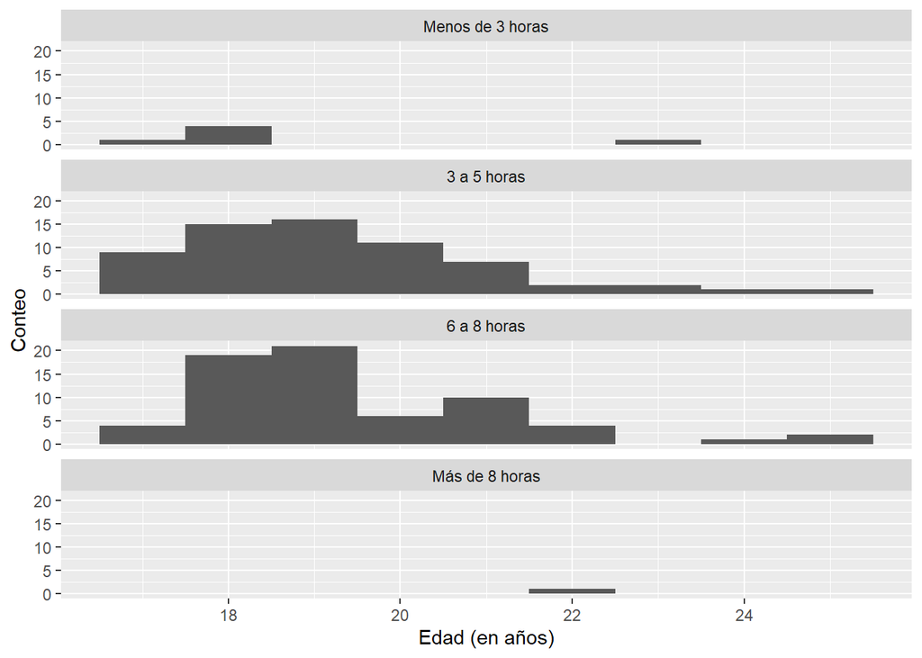

```r
DP$type2 <- reorder(DP$TiempoS, DP$Edad)
ggplot(DP, aes(x = Edad))  +
  geom_histogram(binwidth = 1) +
  xlab("Edad (en años)") +
  ylab("Conteo") +
  facet_wrap(~ type2, ncol = 1)
```

Utilidad: El gráfico muestra la relación entre la edad y las horas de sueño. Nos permite saber si los estudiantes han dormido lo suficiente de manera general. Observamos que existe una mayor cantidad de estudiantes que duermen entre 3 y 8 horas, independientemente de sus edades. Esto resulta alarmante debido a que ya sean adultos jóvenes o adolescentes, deben dormir de 6 a más horas.

2. Relación entre los grupos etarios (adolescentes y adultos jóvenes) y la cantidad de horas de sueño:

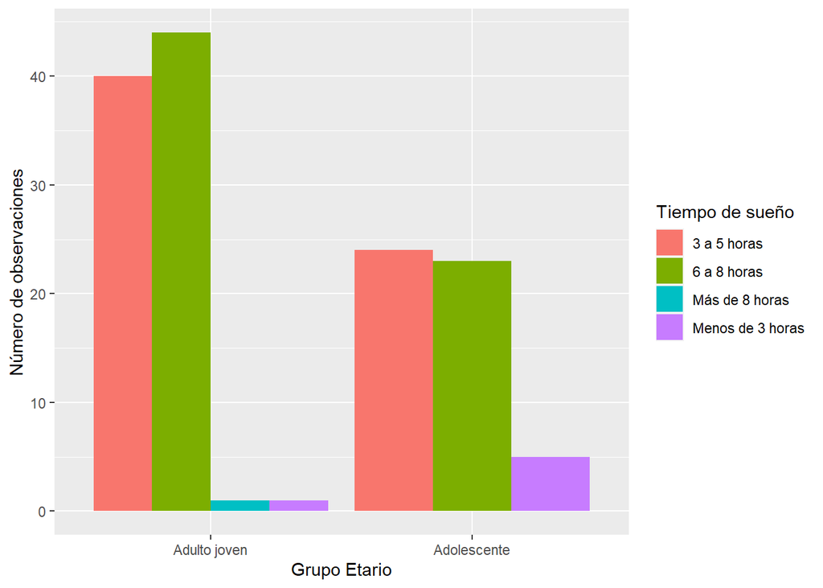

```r
ca <- c("Adulto joven", "Adolescente")
DP$GEtario <- ifelse(DP$Edad > 18, "Adulto joven", "Adolescente")
ggplot(DP, aes(x = GEtario, fill = TiempoS)) +
  geom_bar(position = "dodge") +
  scale_x_discrete(limits = ca) +
  labs(x = "Grupo Etario", y = "Número de observaciones", fill = "Tiempo de sueño")
```

Utilidad: Notamos que, a pesar de la diferencia de edad entre ambos grupos, el comportamiento es muy similar. Gran parte de ambos grupos etarios toman entre 3 a 5 horas o entre 6 a 8 horas en dormir. Si tomamos en cuenta las investigaciones de The Sleep Foundation (2023), quienes nos indican que los adolescentes (de 13 a 18 años) deben dormir de 8 a 10 horas y los adultos (de 18 a más) deben dormir de 6 a 8 horas para tener un rendimiento óptimo durante el día, podemos concluir que los adolescentes no están durmiendo las suficientes horas al día. En el caso de los adultos jóvenes, podemos concluir que si bien hay muchos adultos que cumplen con el tiempo necesario de sueño, para tener un buen rendimiento durante el día, estos forman parte de un poco más del 50% de las muestras, mientras que el resto solo duermen de 3 a 5 horas (incluso menos, pero en una cantidad mínima).

3. Relación entre las horas de sueño y el desempeño académico:

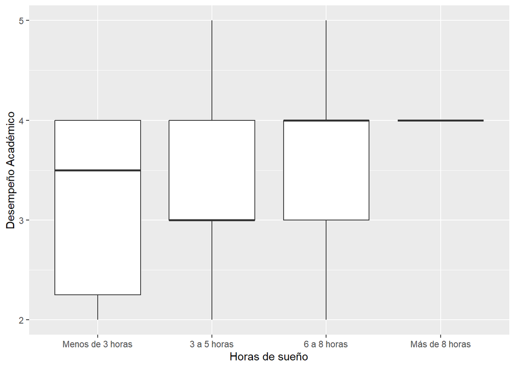

```r
o <- c("Menos de 3 horas","3 a 5 horas","6 a 8 horas","Más de 8 horas")
ggplot(DP, aes(x = TiempoS, y = DesempeñoA)) +
  geom_boxplot() +
  scale_x_discrete(limits = o) +
  labs(x = "Horas de sueño", y = "Desempeño Académico")
```

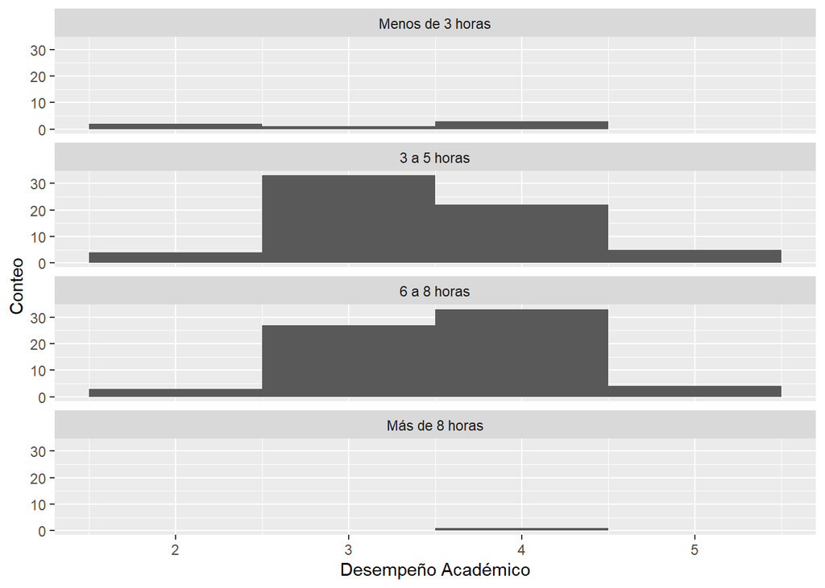

```r
DP$type <- reorder(DP$TiempoS, DP$DesempeñoA)
ggplot(DP, aes(x = DesempeñoA))  +
  geom_histogram(binwidth = 1) +
  xlab("Desempeño Académico") +
  ylab("Conteo") +
  facet_wrap(~ type, ncol = 1)
```

Utilidad: El histograma nos es útil puesto que complementa la información presentada en el gráfico anterior. Observamos que mientras más duermen los estudiantes mayor es su desempeño académico, esto lo notamos comparando las observaciones correspondientes a estudiantes que duermen de 3 a 5 horas y de 6 a 8 horas.

4. Relación entre las horas de sueño y el desempeño académico de acuerdo a la carrera:

Separamos las carreras por grupos para tener los datos mejor proporcionados, esto es por la diferencia en la cantidad de estudiantes por carrera. La idea principal era que sean separados por carreras y así analizar si existe algún tipo de variación en los resultados. Sin embargo, la cantidad de observaciones que están relacionadas a algunas carreras son muy pocas en comparación con la cantidad de observaciones que tienen otras, por lo que considerábamos inviable el poder comparar sus gráficos de esa manera. Así que optamos por agruparlas de esta otra forma.

```r
ELMT <- filter(DP, Carrera %in% c('Ingeniería Mecatrónica', 'Ingeniería Electrónica'))
Biochamp <- filter(DP, Carrera %in% c('Bioingeniería', 'Ingeniería Ambiental', 'Ingeniería Química'))
Concreto <- filter(DP, Carrera %in% c('Ingeniería Civil', 'Ciencia de Datos', 'Ciencia de la Computación'))
WallStreet <- filter(DP, Carrera %in% c('Administración y Negocios Digitales', 'Ingeniería Industrial'))
MecaWatts <- filter(DP, Carrera %in% c('Ingeniería de la Energía', 'Ingeniería Mecánica'))
```

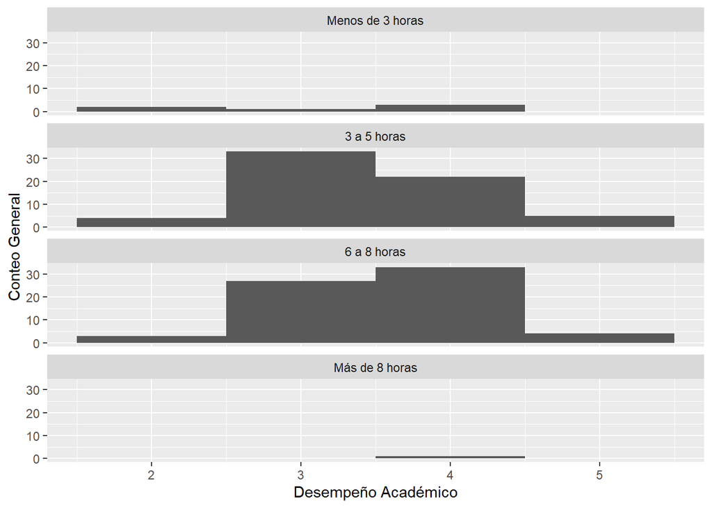

```r
#General
DP$type <- reorder(DP$TiempoS, DP$DesempeñoA)
ggplot(DP, aes(x = DesempeñoA))  +
  geom_histogram(binwidth = 1) +
  xlab("Desempeño Académico") +
  ylab("Conteo General") +
  facet_wrap(~ type, ncol = 1)
```

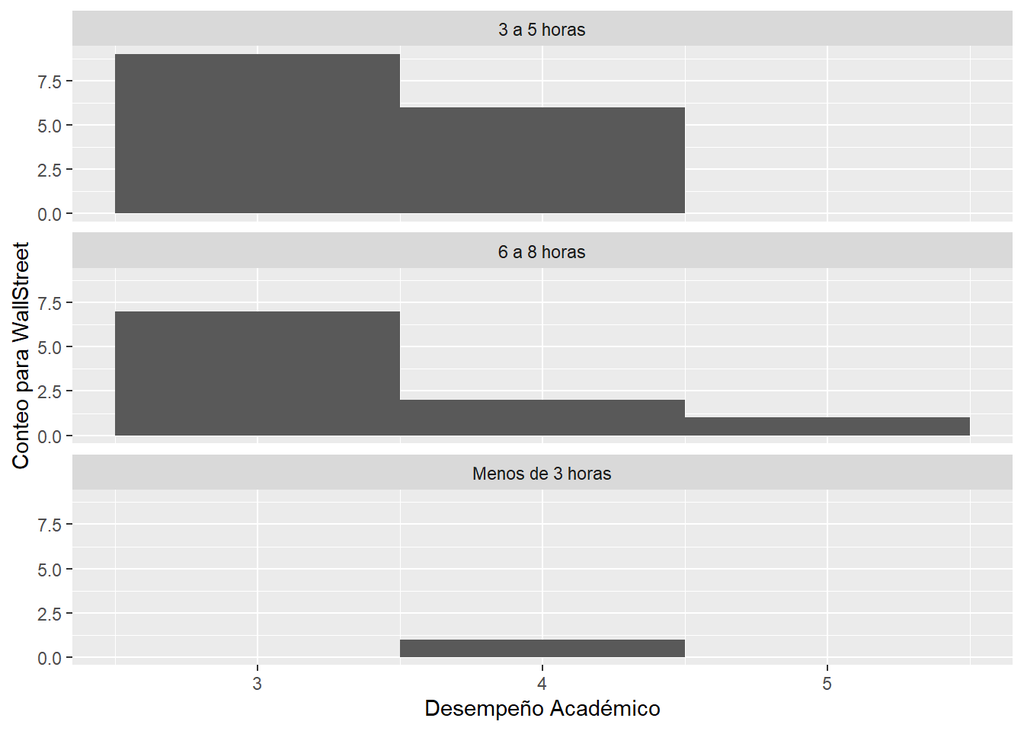

```r
# Para WallStreet
WallStreet$type <- reorder(WallStreet$TiempoS, WallStreet$DesempeñoA)
ggplot(WallStreet, aes(x = DesempeñoA))  +
  geom_histogram(binwidth = 1) +
  xlab("Desempeño Académico") +
  ylab("Conteo para WallStreet") +
  facet_wrap(~ type, ncol = 1)
```

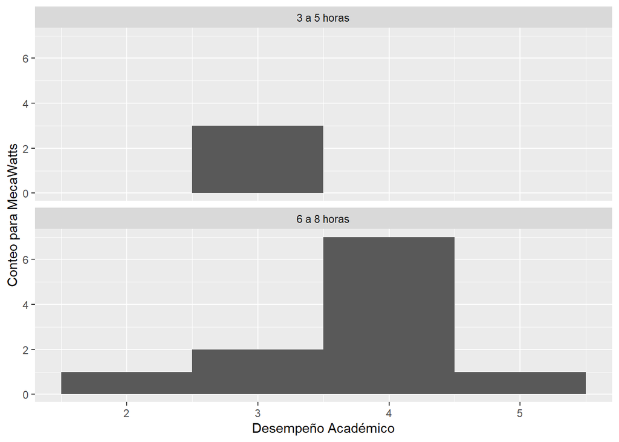

```r
# Para MecaWatts
MecaWatts$type <- reorder(MecaWatts$TiempoS, MecaWatts$DesempeñoA)
ggplot(MecaWatts, aes(x = DesempeñoA))  +
  geom_histogram(binwidth = 1) +
  xlab("Desempeño Académico") +
  ylab("Conteo para MecaWatts") +
  facet_wrap(~ type, ncol = 1)
```

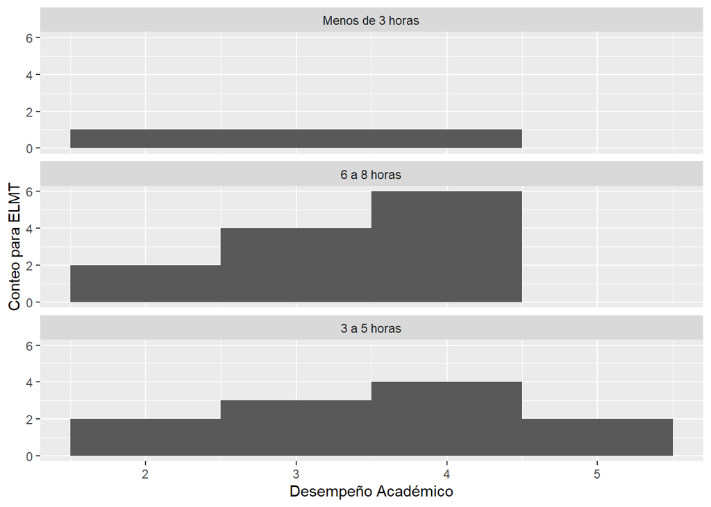

```r
#Para ELMT
ELMT$type <- reorder(ELMT$TiempoS, ELMT$DesempeñoA)
ggplot(ELMT, aes(x = DesempeñoA))  +
  geom_histogram(binwidth = 1) +
  xlab("Desempeño Académico") +
  ylab("Conteo para ELMT") +
  facet_wrap(~ type, ncol = 1)
```

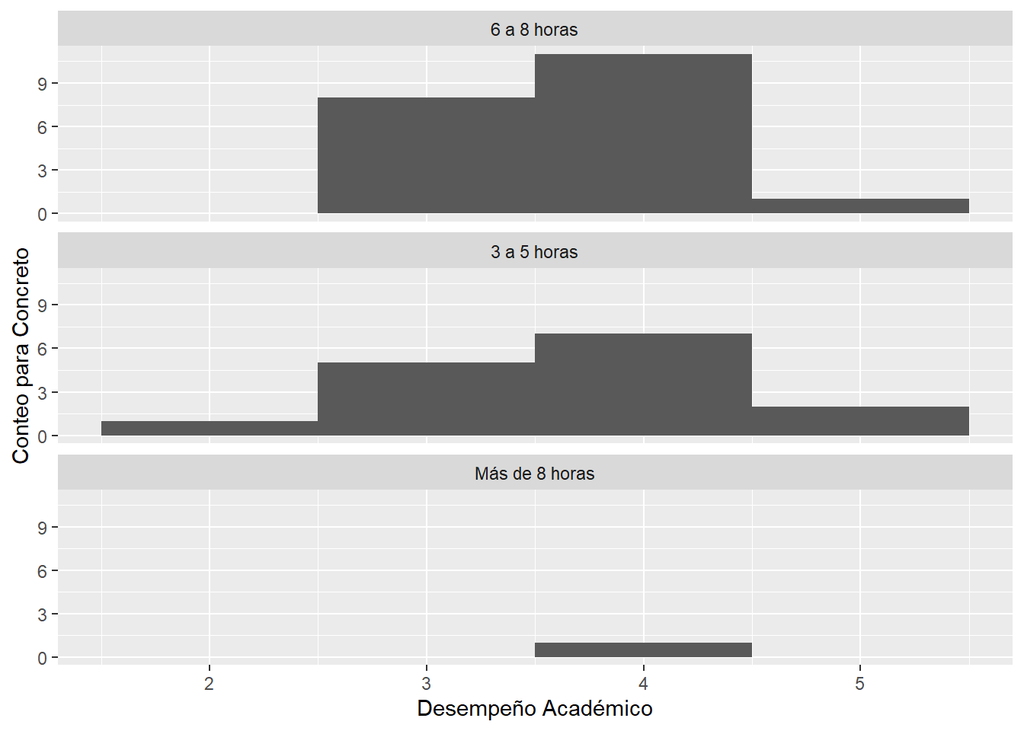

```r
#Para Concreto
Concreto$type <- reorder(Concreto$TiempoS, Concreto$DesempeñoA)
ggplot(Concreto, aes(x = DesempeñoA))  +
  geom_histogram(binwidth = 1) +
  xlab("Desempeño Académico") +
  ylab("Conteo para Concreto") +
  facet_wrap(~ type, ncol = 1)
```

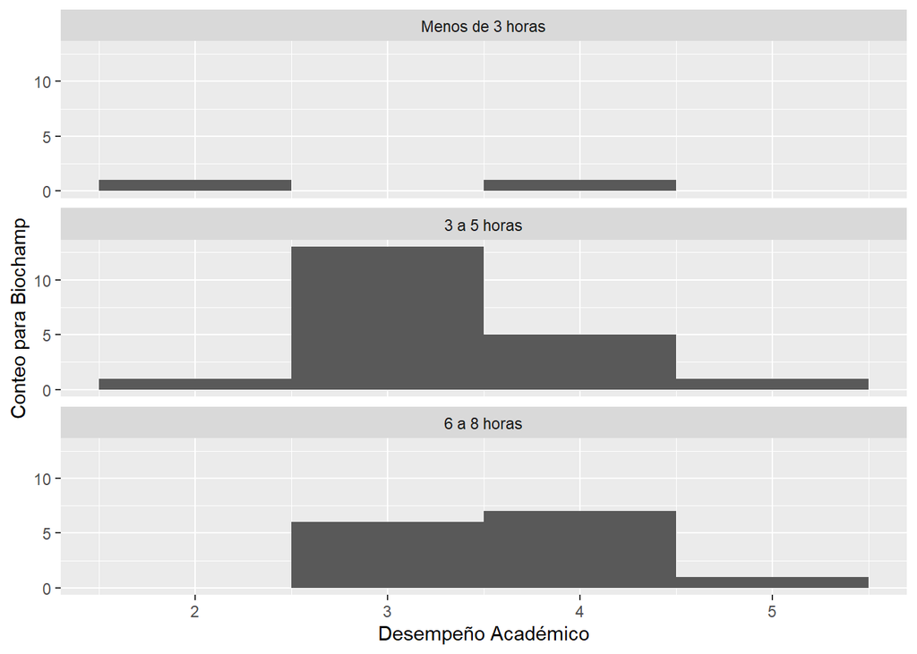

```r
#Para Biochamp
Biochamp$type <- reorder(Biochamp$TiempoS, Biochamp$DesempeñoA)
ggplot(Biochamp, aes(x = DesempeñoA))  +
  geom_histogram(binwidth = 1) +
  xlab("Desempeño Académico") +
  ylab("Conteo para Biochamp") +
  facet_wrap(~ type, ncol = 1)
```

Utilidad: Podemos observar con mayor claridad cómo influyen las horas de sueño en el desempeño académico. Además relacionamos esta información con las carreras para complementar la información mostrada anteriormente. Utilizamos los histogramas debido a que muestran la información de manera más detallada y concisa.

5. Relación entre los grupos etarios y el tiempo de sueño de acuerdo a la carrera:

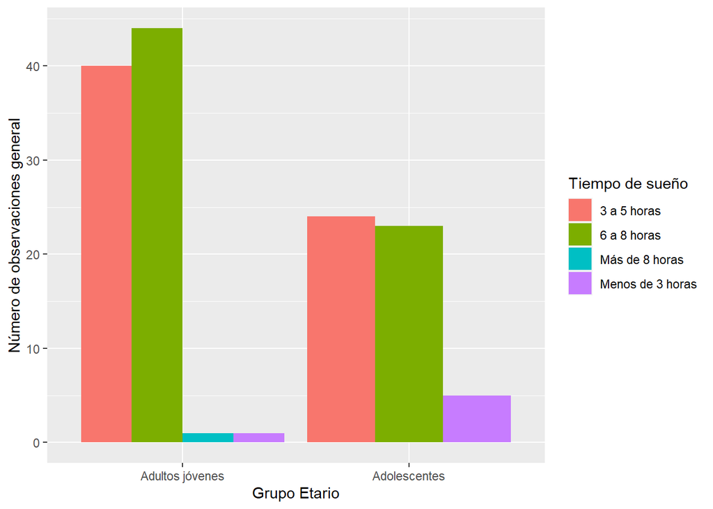

```r
#General
ca <- c("Adultos jóvenes", "Adolescentes")
DP$GEtario <- ifelse(DP$Edad > 18, "Adultos jóvenes", "Adolescentes")
ggplot(DP, aes(x = GEtario, fill = TiempoS)) +
  geom_bar(position = "dodge") +
  scale_x_discrete(limits = ca) +
  labs(x = "Grupo Etario", y = "Número de observaciones general", fill = "Tiempo de sueño")
```

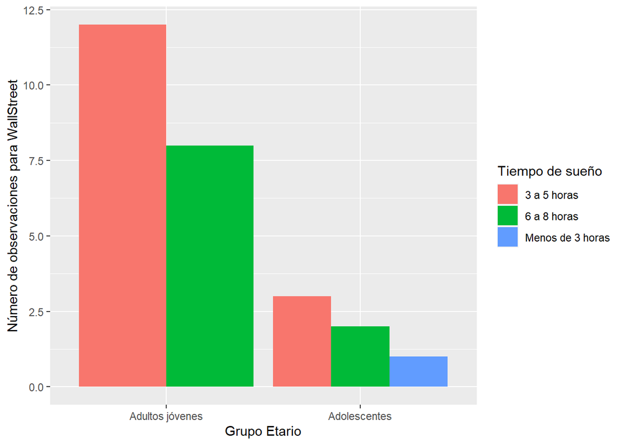

```r
#Para WallStreet

WallStreet$GEtario <- ifelse(WallStreet$Edad > 18, "Adultos jóvenes", "Adolescentes")
ggplot(WallStreet, aes(x = GEtario, fill = TiempoS)) +
  geom_bar(position = "dodge") +
  scale_x_discrete(limits = ca) +
  labs(x = "Grupo Etario", y = "Número de observaciones para WallStreet", fill = "Tiempo de sueño")
```

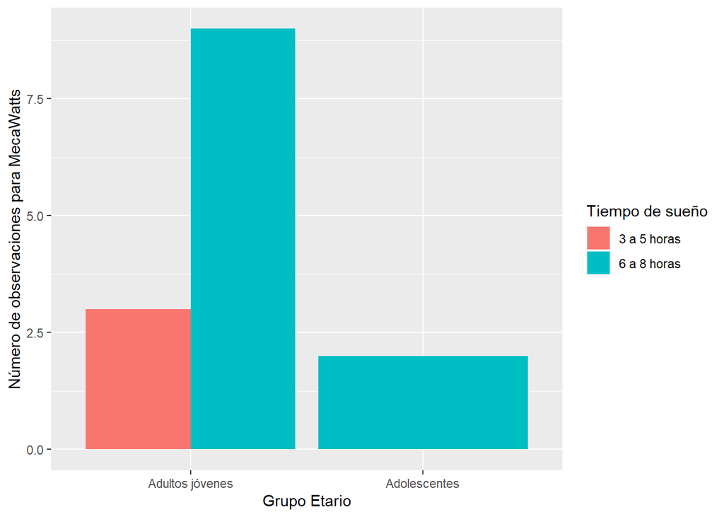

```r
#Para MecaWatts

MecaWatts$GEtario <- ifelse(MecaWatts$Edad > 18, "Adultos jóvenes", "Adolescentes")
ggplot(MecaWatts, aes(x = GEtario, fill = TiempoS)) +
  geom_bar(position = "dodge") +
  scale_x_discrete(limits = ca) +
  labs(x = "Grupo Etario", y = "Número de observaciones para MecaWatts", fill = "Tiempo de sueño")
```

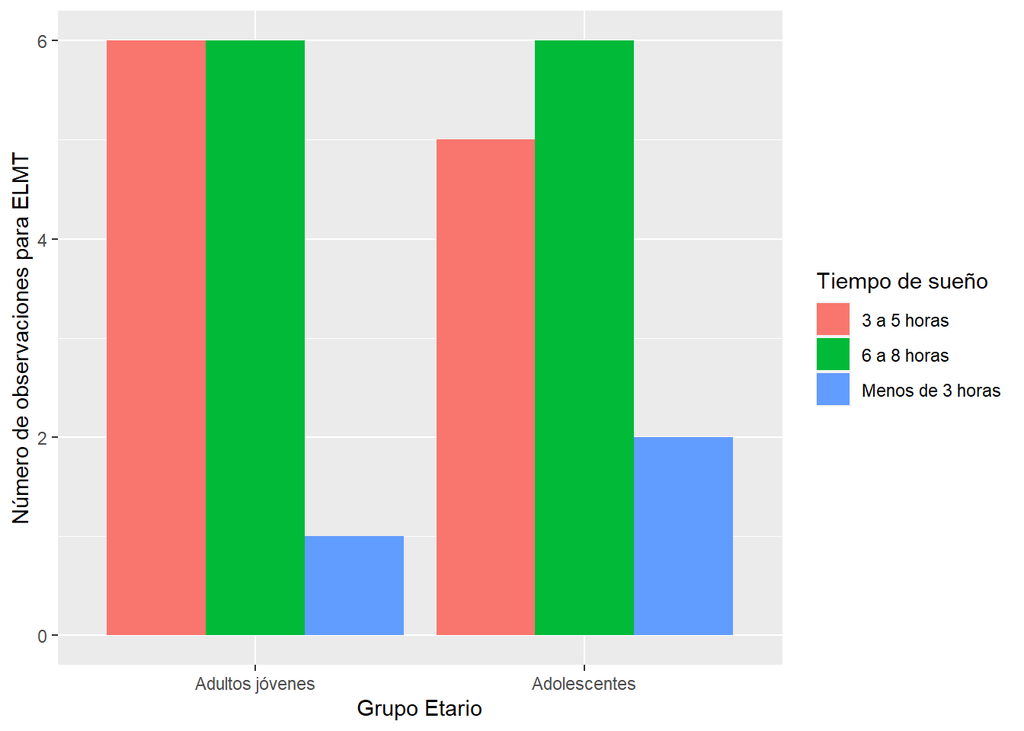

```r
#Para ELMT

ELMT$GEtario <- ifelse(ELMT$Edad > 18, "Adultos jóvenes", "Adolescentes")
ggplot(ELMT, aes(x = GEtario, fill = TiempoS)) +
  geom_bar(position = "dodge") +
  scale_x_discrete(limits = ca) +
  labs(x = "Grupo Etario", y = "Número de observaciones para ELMT", fill = "Tiempo de sueño")
```

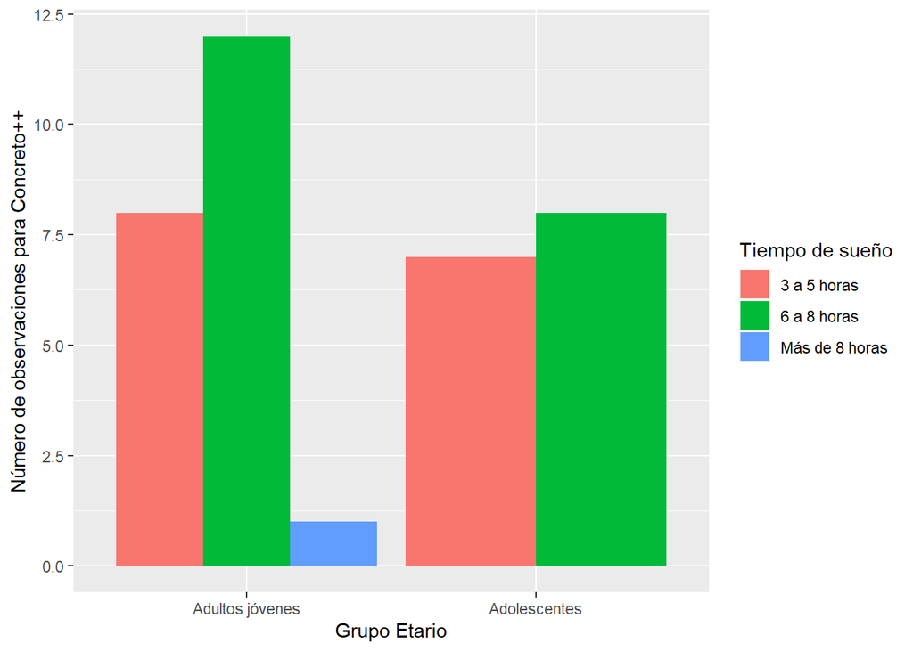

```r
#Para Concreto

Concreto$GEtario <- ifelse(Concreto$Edad > 18, "Adultos jóvenes", "Adolescentes")
ggplot(Concreto, aes(x = GEtario, fill = TiempoS)) +
  geom_bar(position = "dodge") +
  scale_x_discrete(limits = ca) +
  labs(x = "Grupo Etario", y = "Número de observaciones para Concreto++", fill = "Tiempo de sueño")
```

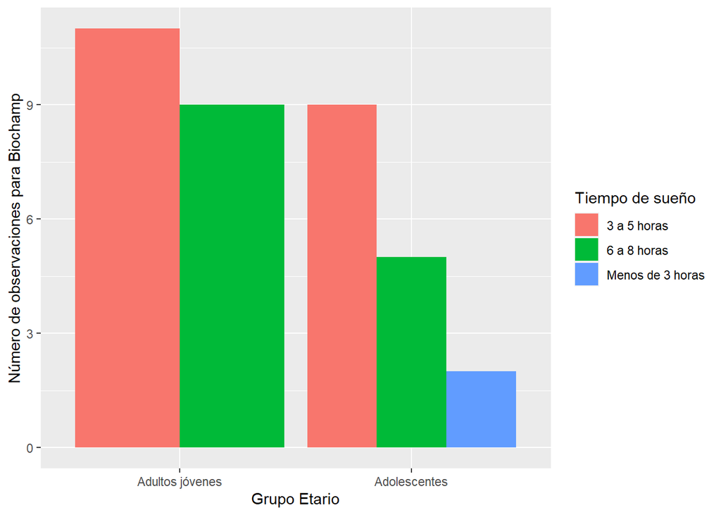

```r
#Para Biochamp

Biochamp$GEtario <- ifelse(Biochamp$Edad > 18, "Adultos jóvenes", "Adolescentes")
ggplot(Biochamp, aes(x = GEtario, fill = TiempoS)) +
  geom_bar(position = "dodge") +
  scale_x_discrete(limits = ca) +
  labs(x = "Grupo Etario", y = "Número de observaciones para Biochamp", fill = "Tiempo de sueño")
```

Utilidad: Los histogramas nos muestran la relación entre los grupos etarios y el tiempo de sueño según las carreras (organizadas por los grupos conformados durante la semana universitaria). Esto nos permite examinar cómo el tiempo de sueño puede variar entre diferentes grupos de edad en relación con las diferentes carreras. Podemos identificar que la mayoría de los estudiantes, adolescentes y adultos jóvenes, duermen entre 3 y 8 horas. Siendo que los adultos jóvenes presentan una mayor cantidad de personas que duermen de 6 a 8 horas y los adolescentes presentan una cantidad similar de datos (3 a 5 horas y 6 a 8 horas). Además, notamos que en los grupos de carreras MecaWatts y Concreto poseen mayor cantidad de personas que duermen de 6 a 8 horas.

6. Relación del tiempo de sueño con el ciclo académico:

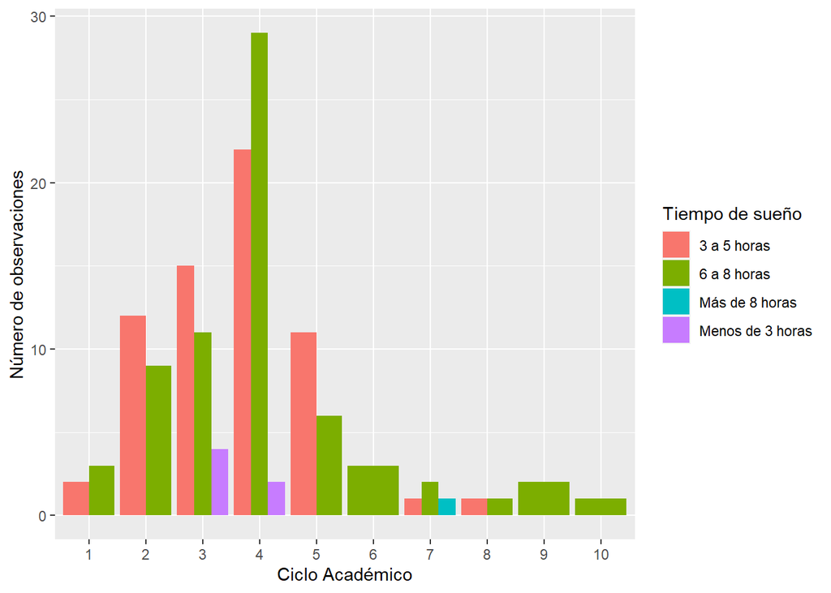

```r
b <- c("1","2","3","4","5","6","7","8","9","10")
ggplot(DP, aes(x = Ciclo, fill = TiempoS)) +
  geom_bar(position = "dodge") +
  scale_x_discrete(limits = b) +
  labs(x = "Ciclo Académico", y = "Número de observaciones", fill = "Tiempo de sueño")
```

7. Relación entre la fatiga y el tiempo de sueño:

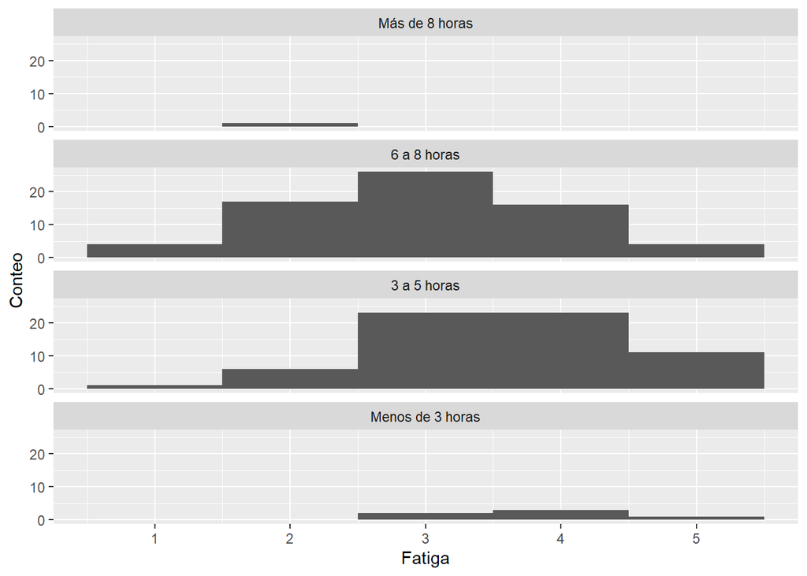

```r
DP$type <- reorder(DP$TiempoS, DP$Fatiga)
ggplot(DP, aes(x = Fatiga))  +
  geom_histogram(binwidth = 1) +
  xlab("Fatiga") +
  ylab("Conteo") +
  facet_wrap(~ type, ncol = 1)
```

Utilidad: El gráfico nos muestra la relación entre la fatiga y el tiempo de sueño. Esta información es útil porque nos permite comprender cómo el tiempo de sueño puede afectar los niveles de fatiga y su importancia. Observamos que existe una relación significativa entre estas dos variables, siendo que mientras mayor son las horas de sueño, menor es la fatiga. Sin embargo, las personas que duermen de 6 a 8 horas presentan niveles de fatiga variados, esto ocurre porque la cantidad de sueño no es el único factor que ocasiona fatiga, debemos considerar factores como actividades extracurriculares, estrés y la calidad del sueño.

8. Relación entre la frecuencia de realización de ejercicios físicos y los grupos etarios:

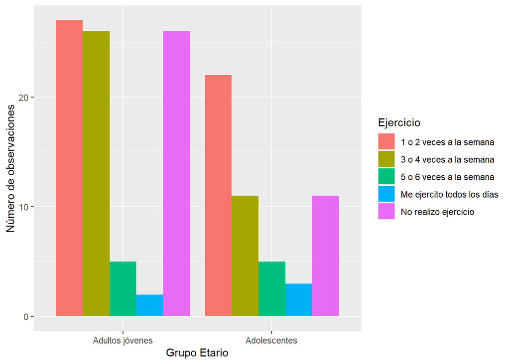

```r
ggplot(DP, aes(x = GEtario, fill = Ejercicio)) +
  geom_bar(position = "dodge") +
  scale_x_discrete(limits = ca) +
  labs(x = "Grupo Etario", y = "Número de observaciones", fill = "Ejercicio")
```

Utilidad: El gráfico nos muestra la relación entre la frecuencia de realización de ejercicios físicos y los grupos etarios. Esta información es útil porque nos permite analizar cómo se distribuye la práctica de ejercicio en diferentes grupos de edad. Observamos que ambos grupos etarios se ejercitan en su mayoría por lo menos una o dos veces a la semana. Sin embargo, los adultos jóvenes poseen una cantidad de personas que no realizan ejercicio casi igual a la de las que lo realizan una o dos veces a la semana. Además, notamos que los adolescentes presentan una menor cantidad de personas que no realizan ejercicio.

9. Relación entre el nivel de estrés y el tiempo de sueño:

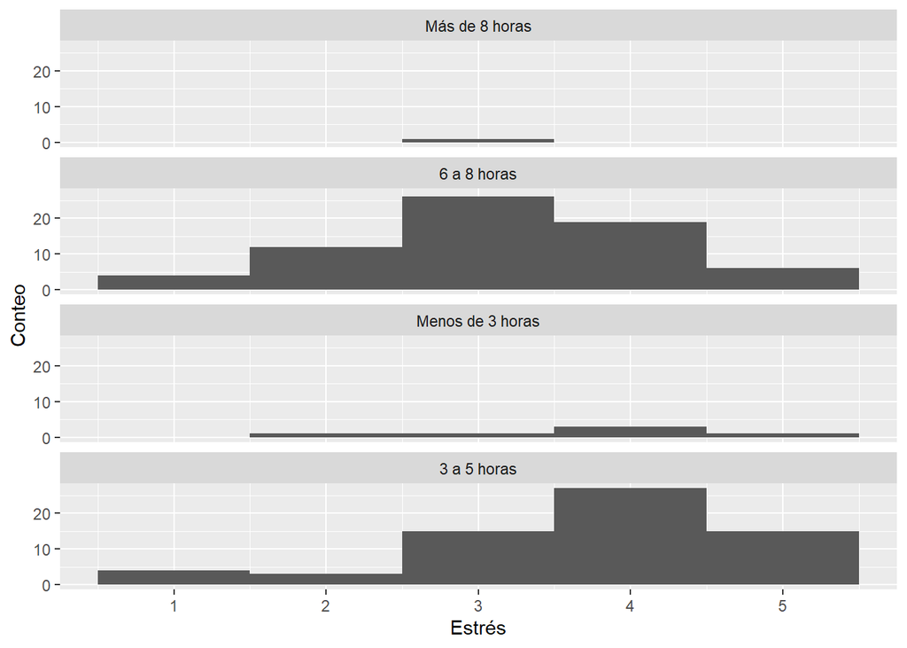

```r
DP$te <- reorder(DP$TiempoS, DP$NEstres)
ggplot(DP, aes(x = NEstres))  +
  geom_histogram(binwidth = 1) +
  xlab("Estrés") +
  ylab("Conteo") +
  facet_wrap(~ te, ncol = 1)
```

Utilidad: El gráfico nos muestra la relación entre el nivel de estrés y el tiempo de sueño. Esta información es útil porque nos permite explorar cómo el tiempo de sueño puede influir en el nivel de estrés de una persona y viceversa. Al observar el gráfico, podemos identificar una relación negativa entre el tiempo de sueño y el nivel de estrés, lo que significa que a medida que aumenta el tiempo de sueño, el nivel de estrés tiende a disminuir. Esto indica la importancia de un sueño adecuado para reducir el estrés y mantener un equilibrio emocional saludable.

10. Relación entre el nivel de estrés y el ciclo académico:

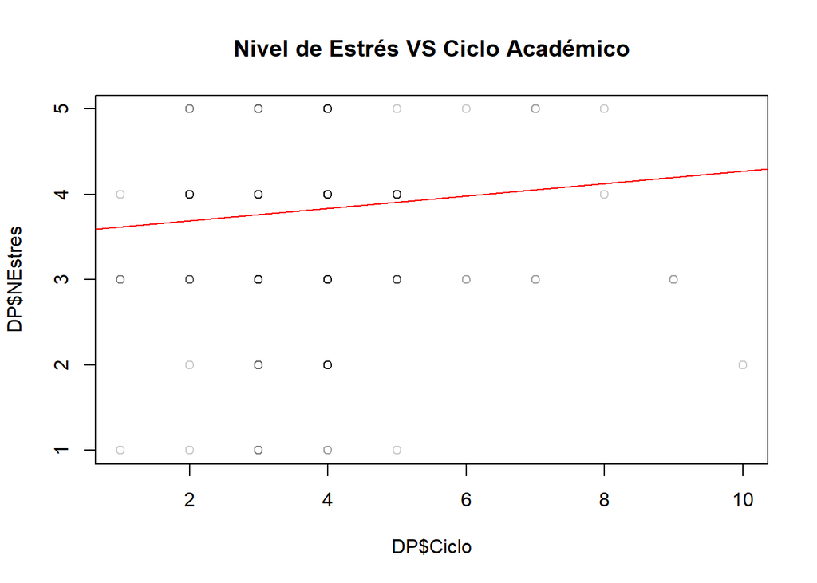

```r
plot(DP$Ciclo,DP$NEstres,pch =1,col=rgb(0,0,0,0.2))
abline(lm(DP$Ciclo~DP$NEstres), col="red")
title(main = "Nivel de Estrés VS Ciclo Académico")
```

Utilidad: La gráfica de dispersión muestra la relación entre el nivel de estrés y el ciclo académico de los estudiantes de UTEC. A pesar de trazar una recta de regresión lineal para analizar la relación, se puede concluir que no existe una relación fuerte entre estas dos variables. Los puntos dispersos en el gráfico y la pendiente casi horizontal de la recta de regresión sugieren que no hay una asociación clara entre el nivel de estrés y el ciclo académico de los estudiantes. Esto indica que el ciclo académico en el que se encuentran los estudiantes no es un factor determinante del nivel de estrés.

11. Relación entre los grupos etarios y las horas de estudio:

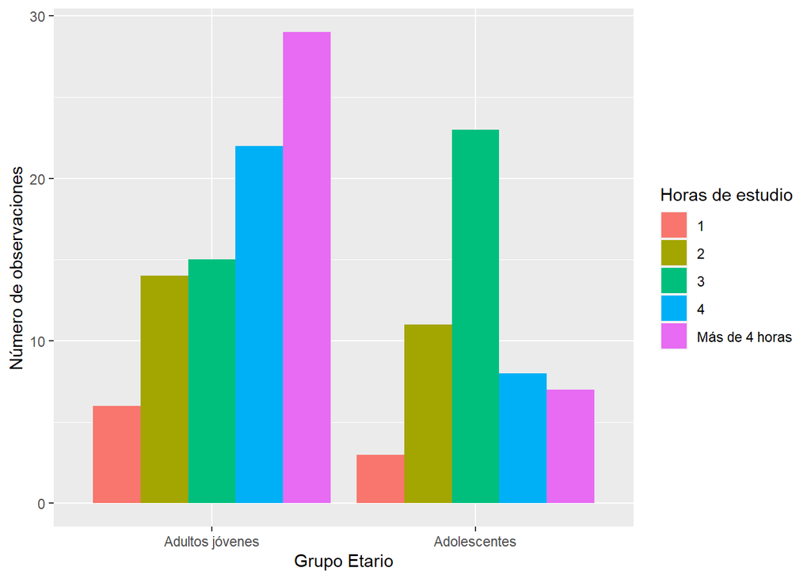

```r
ggplot(DP, aes(x = GEtario, fill = HEstudio)) +
  geom_bar(position = "dodge") +
  scale_x_discrete(limits = ca) +
  labs(x = "Grupo Etario", y = "Número de observaciones", fill = "Horas de estudio")
```

Utilidad: El gráfico nos muestra la relación entre los grupos etarios y las horas de estudio. Esta información es útil porque nos permite analizar cómo se distribuyen las horas de estudio en diferentes grupos de edad y comprender la relación entre el tiempo dedicado al estudio y la edad de los estudiantes. Al observar el gráfico, podemos identificar patrones o tendencias en la cantidad de horas de estudio en cada grupo etario. Esto es relevante para comprender los hábitos de estudio de los diferentes grupos de edad y cómo esto puede influir en su rendimiento académico. Podemos observar que los adultos jóvenes dedican una mayor catidad de horas de estudio en comparación con los adolescentes.

12. Relación entre el tiempo de sueño y la calidad de sueño:

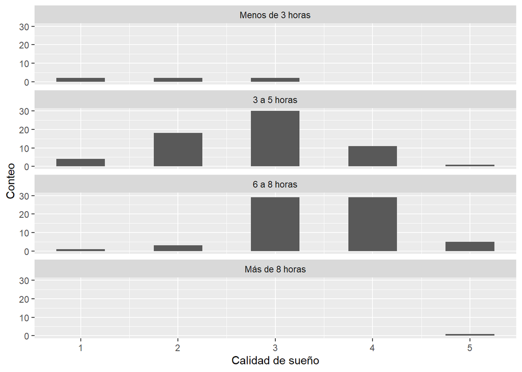

```r
DP$type <- reorder(DP$TiempoS, DP$CalidadS)
ggplot(DP, aes(x = CalidadS))  +
  geom_histogram(binwidth = 0.5) +
  xlab("Calidad de sueño") +
  ylab("Conteo") +
  facet_wrap(~ type, ncol = 1)
```

Utilidad: El gráfico muestra la relación entre la calidad del sueño y el número de horas de sueño de los estudiantes de UTEC. La mayoría de los estudiantes presenta una calidad de sueño regular o buena. Se observa que la mayoría de los estudiantes duermen de 3 a 8 horas. Además, se confirma una relación entre las horas de sueño y la calidad del mismo: a medida que disminuyen las horas de sueño, la calidad del sueño tiende a empeorar. Esto sugiere que dormir menos horas puede tener un impacto negativo en la calidad del sueño de los estudiantes de UTEC.

13. Relación entre el nivel de estrés y la dificultad para dormir o permanecer dormido:

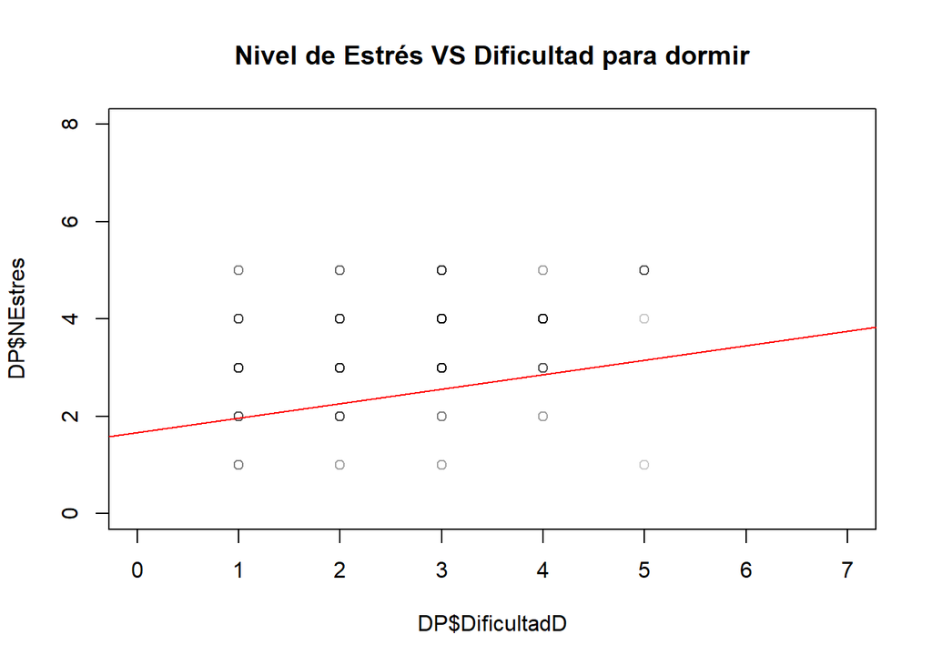

```r
plot(DP$DificultadD,DP$NEstres,pch =1,col=rgb(0,0,0,0.2),xlim = c(0, 7), ylim = c(0, 8))
abline(lm(DP$DificultadD~DP$NEstres), col="red")
title(main = "Nivel de Estrés VS Dificultad para dormir")
```

Utilidad: La gráfica de dispersión muestra la relación entre el nivel de estrés y la dificultad para dormir. Además, se ha trazado una recta de regresión lineal para analizar si existe una relación significativa entre ambas variables. Al observar el gráfico, notamos que no existe una relación fuerte entre estas variables, esto es por los puntos dispersos a lo largo del gráfico y la pendiente casi horizontal de la recta de regresión.

14. Gráfico de barras sobre la cantidad de bebidas energizantes consumidas:

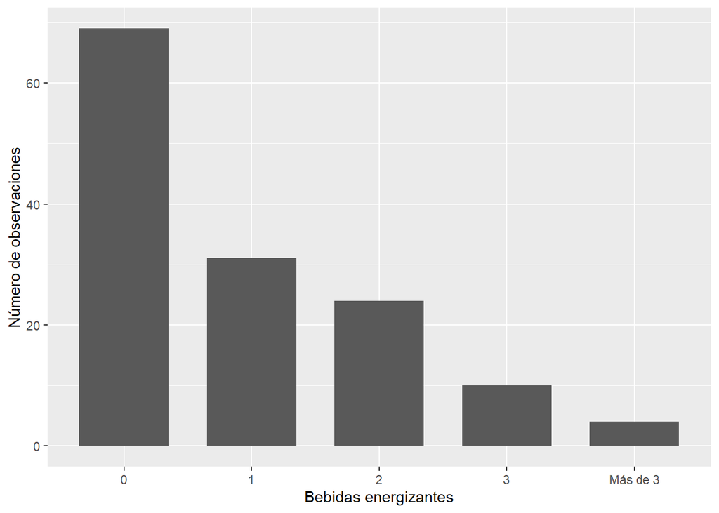

```r
ggplot(DP, aes(x = Bcafeina)) +
  geom_bar(width = 0.7) +
  xlab("Bebidas energizantes") + ylab("Número de observaciones")
```

15. Relación entre el insomnio y la opinión de los estudiantes sobre su desempeño académico respecto a la falta de sueño:

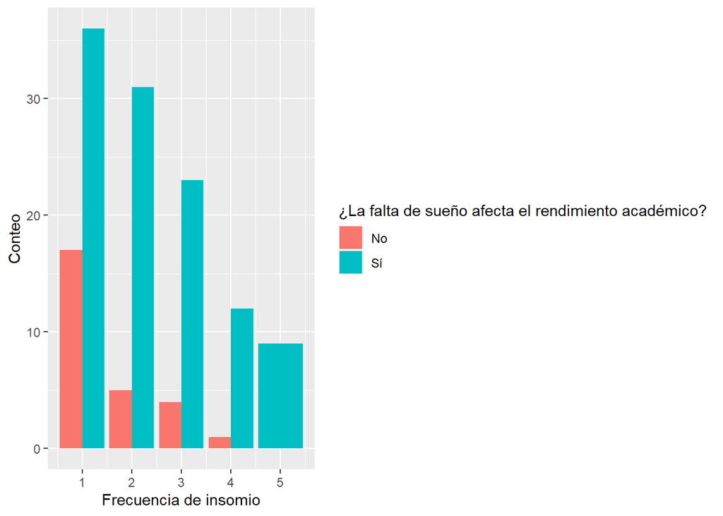

```r
ggplot(DP, aes(x = Insomnio, fill = OpinionRA)) +
  geom_bar(position = "dodge") +
  labs(x = "Frecuencia de insomio", y = "Conteo", fill="¿La falta de sueño afecta el rendimiento académico?")
```

Utilidad: En la gráfica se observa que las personas que presentan altos niveles de insomnio como las que no, en mayor proporción señalan que su rendimiento académico es afectado por sus hábitos de sueño esto hace notar que la mayoría de estudiantes relacionan directamente los problemas o posibles problemas de insomnio con su desempeño.

16. Frecuencia con la que usan dispositivos electrónicos antes de dormir:

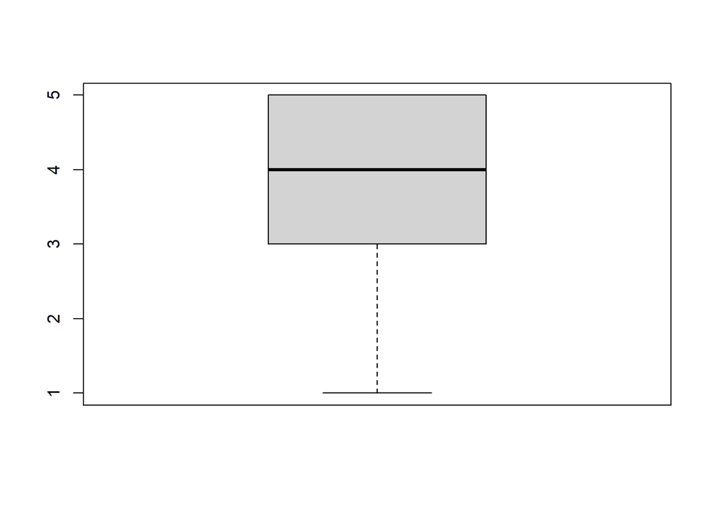

```r
boxplot(DP$DispositivoE)
```

Utilidad: Observamos cómo están distribuidos los datos para DispositivoE. Notamos que la mayoría utiliza dispositivos electrónicos antes de dormir, siendo pocos los que no los hacen. Esto puede afectar a la calidad del sueño y al sentir somnolencia durante el día.

17. Relación noches de estudio y el sentirse abrumado:

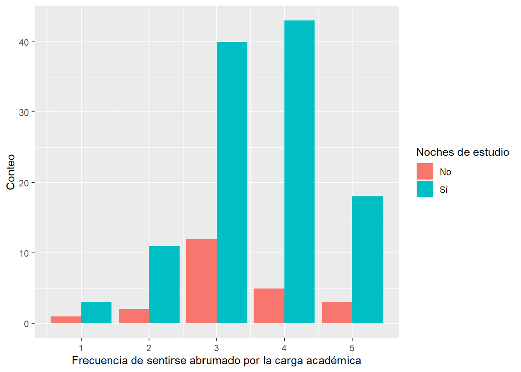

```r
ggplot(DP, aes(x = AbrumadoTA, fill = NocheE)) +
  geom_bar(position = "dodge") +
  labs(x = "Frecuencia de sentirse abrumado por la carga académica", y = "Conteo", fill="Noches de estudio")
```

18. Relación sobre el estrés académico y los compromisos académicos:

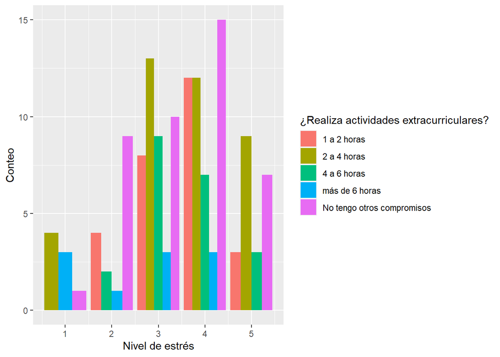

```r
ggplot(DP, aes(x = NEstres, fill = CompromisosE)) +
  geom_bar(position = "dodge") +
  labs(x = "Nivel de estrés", y = "Conteo", fill="¿Realiza actividades extracurriculares?")
```

19. Relación entre los eventos académicos y siestas:

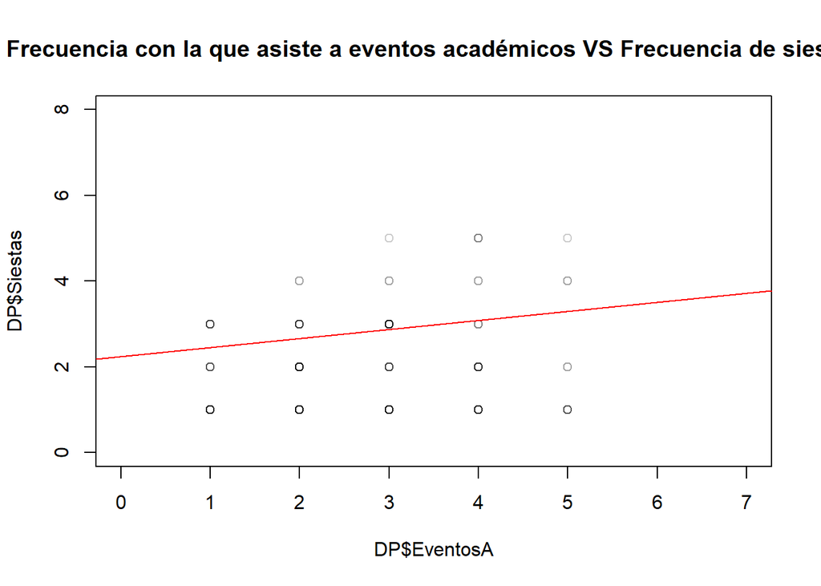

```r
plot(DP$EventosA,DP$Siestas,pch =1,col=rgb(0,0,0,0.2),xlim = c(0, 7), ylim = c(0, 8))
abline(lm(DP$EventosA~DP$Siestas), col="red")
title(main = "Frecuencia con la que asiste a eventos académicos VS Frecuencia de siestas")
```

Utilidad: La gráfica de dispersión muestra la relación entre la frecuencia con la que asiste a eventos académicos y la frecuencia con la que toma siestas. Además, se ha trazado una recta de regresión lineal para analizar si existe una relación significativa entre ambas variables. Notamos que no existe una relación fuerte entre estas variables, esto es por los puntos dispersos a lo largo del gráfico y la pendiente casi horizontal de la recta de regresión.

20. Relación entre la opinión sobre la salud mental y el asesoramiento respecto a esta o hábitos de sueño:

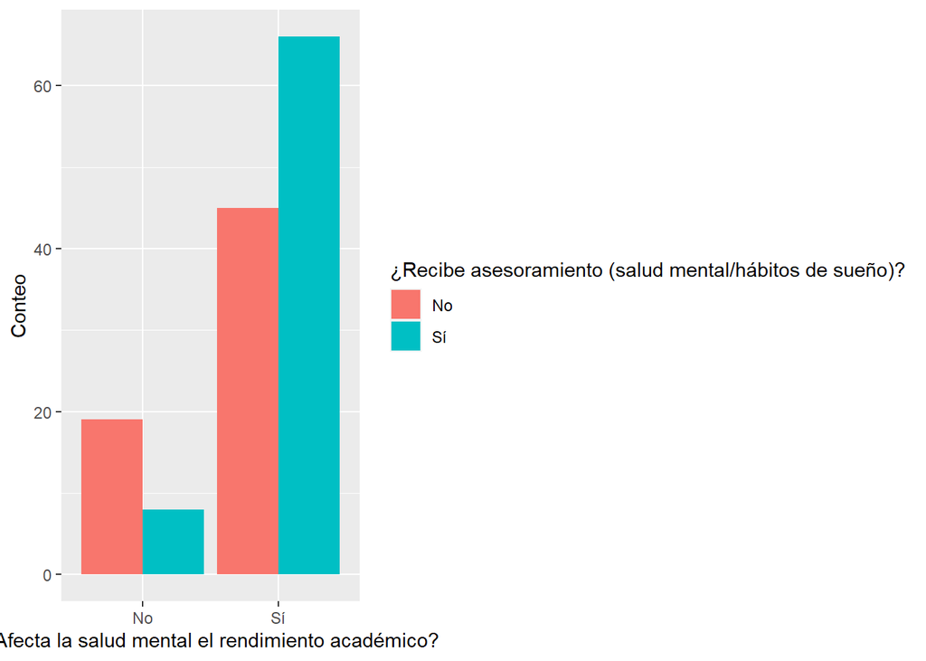

```r
ggplot(DP, aes(x = SaludMental, fill = Consejo)) +
  geom_bar(position = "dodge") +
  labs(x = "¿Afecta la salud mental el rendimiento académico?", y = "Conteo", fill="¿Recibe asesoramiento (salud mental/hábitos de sueño)?")
```

Utilidad: Observamos que la mayoría coincide en que la salud mental está relacionada con el rendimiento académico y gran parte recibe asesoramiento por ello.

# Bibliografía

Adjunto en el archivo zip como “Bibliografía”